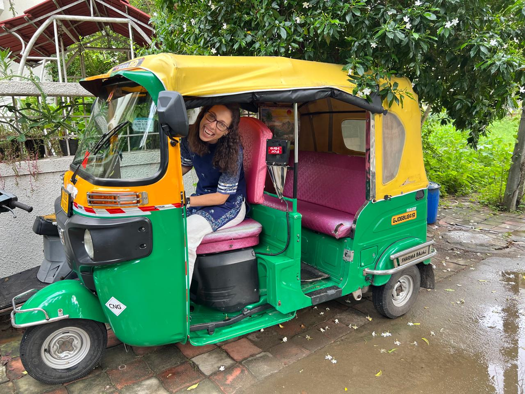

# Mary de Boer

## Education

**Johns Hopkins Bloomberg School of Public Health** | Baltimore, MD

Ph.D. in International Health - Human Nutrition | August 2022 - July 2025

**The London School of Economics** | London, UK

M.Sc. in Health, Community and Development | September 2009 - December 2010

**Pomona College** | Claremont, CA

B.A. in English Literature; Premedical Sciences track | August 2003 - May 2007

## Experience

**Stanford University Woods Institute for the Environment** | Postdoctoral Fellow | March 2026 - Present

**Johns Hopkins Bloomberg School of Public Health** | Postdoctoral Fellow | September 2025 - February 2026

**USAID** | Foreign Service Officer | August 2011 - July 2025

**National Cancer Institute: Center to Reduce Cancer Health Disparities** | Health Communications Fellow | January 2011 - July 2011

**MEA Foundation Buguruni** | Program Evaluator | July 2008 - May 2009

**Swarthmore College** | Undergraduate Writing Program Coordinator | August 2007 - June 2008

**Pomona College** | Writing Fellow and Teaching Assistant | August 2004 - June 2007

**Cleveland Clinic Foundation** | Summer Undergraduate Research Program | June 2005 - August 2005